# 短期集中研修『Rデータ自由自在（入門編）』

三村喬生 (連絡先：kmimura[at]ism.ac.jp)

# 受講のための準備

ネットワーク接続が可能なノートPCを用意してください。  
以下のガイダンスに従い、講義で使用するR環境を設定してください。  
動作確認を済ませ、講義当日にそのPCをご持参ください。

**※ 特にインストールについて受講当日にトラブルが生じると、大幅に時間を要する場合があります。必ず事前に試し、エラーや不明な点が生じた場合は上記連絡先宛に電子メールでお問い合わせください。**

- **【1】Rのインストール**
- **【2】RStudioのインストール**
- **【3】パッケージのインストール**
- **【4】動作確認**
- 【5】RStudioの表示設定のカスタム(適宜)

## 注意事項：講義当日のネットワーク環境について

講義当日は準備済みのノートPCを統数研にご持参ください。

統数研が提供するゲスト用無線LANは、**Mac**もしくは**Windows 10**に対応しておりますが、**Windows 11には対応しておりません**のでご注意ください。それとは別に**eduroam**への接続も可能です。他には個人的にWi-Fiルータをご持参いただく、もしくはテザリングで接続するなどの方法が考えられます。

持参いただく予定のPCについてOSのバージョンなどを確認いただき、どうしても上記の要件に満たないと思われる場合は、**事務局：mhcsec[at]ism.ac.jp**宛にその旨ご連絡ください。

## 【1】 Rのインストール

プログラミング言語Rを実行するためのソフトウェア(ソフトウェア名もR)をインストールします。

**1. 既にRがインストールされている場合**

- 本講義のRコードの動作確認はR version 4.3.2 for MacOSで行っています。
- 本講義ではR version **4.3.0**以降を推奨します。
- 特にこだわりがなければ最新版の利用を推奨します。
- Rを起動し、バージョンを確認してください。
  - Rの起動画面、もしくはコンソール上で`version`もしくは`sessionInfo()`コマンドを実行することでインストールされているRのバージョンを確認できます。

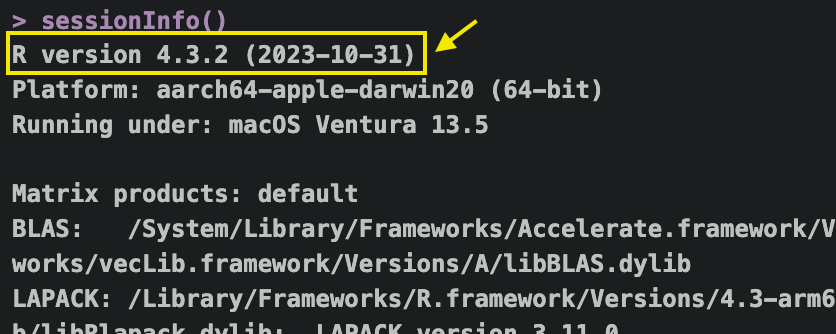

- Rのバージョンを**アップデート**する場合、下記の「2. 初めてRをインストールする場合」と同様の手順を実行してください。その後、Rを再起動し、バージョンが更新されていることを確認してください。
- R ver. 4.2.*もしくはそれ以前のバージョンから最新版にアップデートする場合、インストール済みのRパッケージの使用を継続するためには、パッケージを再インストールする必要があります。
  - 古いパッケージにはエラーや非推奨形式のコードが含まれている可能性もあるため、この機会にアップデート・再インストールすることを推奨します。
  - ただし、古いパッケージの中には最新版のRに対応していないものが含まれている可能性があります。このようなパッケージはアップデートしたRには再インストールできず、使用できなくなるケースがあります。使用を継続したいパッケージのWebサイトで対応するRのバージョンを確認するなど、十分ご注意ください。
  - どうしてもR ver. 4.2以前のバージョンで受講したいという方は、利用したいRに関する情報を添えて個別にご相談ください（ただしR 3.*.*以前のバージョンには対応できません）。

**2. 初めてRをインストールする場合**

- [ダウンロードサイト(CRAN 統数研 ミラーサイト)](https://cran.ism.ac.jp/)にアクセスします。
- OS(Linux/MacOS/Windows)を選択します。
  - MacOSの場合
    - Download R for macOS → **R-4.3.2-arm64.pkg**をダウンロードして、インストール

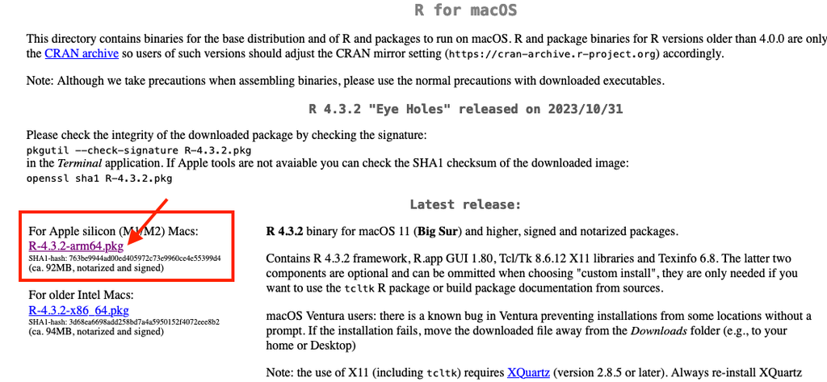

  - Windowsの場合
    - Download R for Windows → **install R for first time** → **Download R-4.3.2 for Windows**から**R-4.3.2.exe**をダウンロードして、インストール
    - コンポーネントの選択：「利用者向けインストール」
    - 起動時オプション：「いいえ」

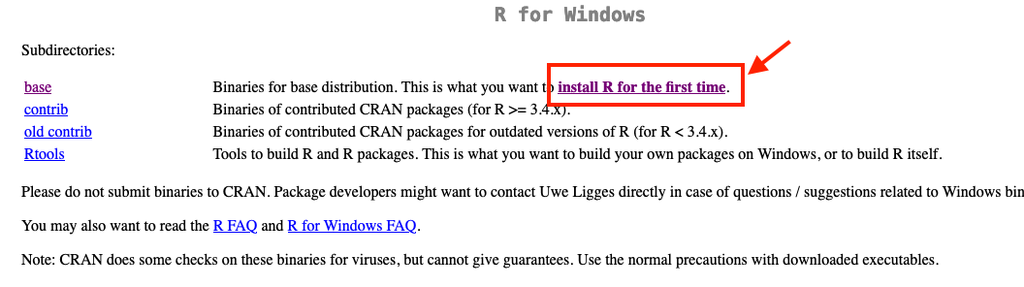

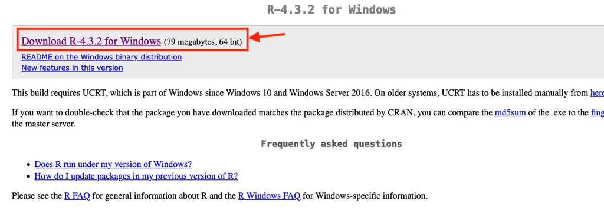

  - Linuxの場合：OSを選択し適宜インストール
    - インストールできない場合は個別にご相談ください。
    - 環境によってはインストール方法のご案内が難しい場合があります。Linuxにおけるプログラミング環境の構築に習熟していない場合、本講義においてはMacOS/Windowsの利用、もしくは下記にご案内するPosit Cloudの利用をお勧めします。Posit Cloudでの受講を希望し、設定がわからない方は個別にお問い合わせください。

## 【2】 RStudioのインストール

Rを利用する際、Rプログラミングを支援する様々な補助機能を備えたアプリケーション(いわゆる統合開発環境, Integrated Development Environment, IDE)である**RStudio Desktop**の利用(無料)を推奨します。本講義ではRStudioの利用法についても解説しますので、会場に持参するPCに予めインストールしてください。

- 講師の環境は2023年10月時点における最新版である**RStudio-2023.09.01 Build 494**です。
- RStudioには開発者であるPosit社が用意しているCloud版（[Posit Cloud](https://posit.cloud/plans?utm_source=Website&utm_medium=IDE_Download)）もあります。Posit CloudにログインするとPC環境に依存せずに最新版のR/RStudioを手軽に利用できます。本講義のみについて言えば、予習・復習を含めて利用上限に収まる可能性もありますが、継続的な利用にはRStudio for Desktop(無料)もしくはPosit Cloudの有償版の利用を推奨します。
  - 無償版Posit Cloudの制限内容
  - 建てられるプロジェクト数：最大25プロジェクト
  - 作業時間：25時間/月
  - RAM：1GB
- RStudio以外のIDE(VSCodeなど)を既に利用されていて自信を持って運用できる方は無理にRStudioを利用する必要はありません。ただし、講義内容と合わない部分のすり合わせについては各自の責任で行なってください。

**1. 既にRStudioがインストールされている場合**

- Help → About RStudioからバージョンを確認することができます。

[figure not shown]

- Help → Check for Updatesから最新版をインストールすることができます。

**2. RStudioを初めてインストールする場合**

- [RStudioのダウンロードサイト](https://posit.co/download/rstudio-desktop/)にアクセスする。
- **Install RStudio**からインストールする。

[figure not shown]

## 【3】パッケージのインストール

Rには機能を拡張するための無料のアドイン（これをパッケージと呼びます）が多数用意されています。RのパッケージはR開発チームにより[CRAN (The Comprehensive R Archive Network)](https://cran.r-project.org/) にアーカイブされています。ユーザーはCRANから自由にパッケージをダウンロードして自らのR環境で使用することができます。本講義でも、Rのパッケージを利用しながらデータ科学を学んでいきます。パッケージのインストールは以下の方法で行います。

- RStudioを起動し、Consoleに次のコードを入力しエンターキーを押してください。

```r
install.packages("tidyverse")
```

- ダウンロードメッセージが表示されることを確認してください。
- 続いて以下のコードを入力し、エンターキーを押してください。

```r
library(tidyverse)
```

- 以下の内容が表示されればパッケージが無事に読み込まれ、利用できる状態になりました。

[figure not shown]

- 講義では以下のパッケージを利用します。事前にインストールしておくとスムーズに受講できます。全て`install.packages("パッケージ名")`でインストールすることができます。

| パッケージ名 | 機能 | Webサイト |
| --- | --- | --- |
| **tidyverse** | データ科学関連の総合パッケージ | [link](https://www.tidyverse.org/) |
| **palmerpenguins** | penguinsデータを利用するためのパッケージ | [link](https://allisonhorst.github.io/palmerpenguins/) |
| **lme4** | 混合効果を伴う統計モデリングのためのツール | [link](https://github.com/lme4/lme4/) |
| **patchwork** | データ可視化、図の結合 | [link](https://patchwork.data-imaginist.com/) |

## 【4】動作確認

以下のRコードをいずれかの方法で実行し、グラフが正しく表示されることを確認してください。どのようなグラフが表示されるかは、講義当日に答え合わせします。

1. Consoleに打ち込んで実行(エンターキーを押す)

もしくは

2. 新規スクリプト(File→New File→R Script)を作成し、そこにコードを打ち込む。その後スクリプト全体を選択(**⌘+A** (Mac)もしくは**Ctrl+A** (Windows))して実行(**⌘+↩︎️**もしくは**Ctrl+↩︎**))する。

```r
## packages ----
library(tidyverse)

## parameters ----
r <- 2
x_center <- 1
y_center <- 3

## data ----
df <-
  tibble(
    theta = seq(0, 2 * pi, length = 361),
    X = r * cos(theta) + x_center,
    Y = r * sin(theta) + y_center
  )

## visualization ----
ggplot(data = df) +
  aes(x = X, y = Y) +
  geom_path() +
  coord_fixed()
```

尚、ここからコピペも出来ると思いますが、指の運動のために、実際に手で入力(俗に言う「写経」ですね, 学習効果を高めるためには非常に有効な方法です)してみることをお勧めします。

## 【5】RStudioの表示設定のカスタム

RStudioの初期設定でも問題なく使用することができます。それに加えて個人の好みに応じて表示やショートカットキーなど様々なカスタムを加えることができます。講義で共有する講師の画面と配置や色が違っていて混乱するということであれば、以下の設定を試してください。

- RStudioを起動すると次のような画面が表示されます。

[figure not shown]

  - **Tools** → **Global Options…**から様々な設定が可能です。例えば**Appearance**のEditor themeを変更することで、ソースコードを好みの見た目に調整することができます。

[figure not shown]

[figure not shown]

    - このようにコードを構造や属性に応じて色分けすることで読み取りやすくする機能をシンタックス・ハイライト(syntax highlighting)と呼びます。
  - 講師はConsoleを右側、Sourceを左側に表示する設定に慣れているので、講義ではその設定で画面を共有します。**Global Options…**の**Pane Layout**で、Consoleと表示されている左上のPaneに表示する内容をドロップダウンからSourceに変更することで同じ設定になります。

[figure not shown]

[figure not shown]

[figure not shown]